# Life & Death of Minor Parties

Michael Škvrňák

February 6, 2016

# Replication materials & coding instructions

## Dataset

I created data-set of all political parties which failed to gain a mandate in a parliamentary elections (elections to the lower house of parliament) in the Czech & Slovak republics and Poland. The data include all minor parties competing in the elections during the following elections:

- Czech Republic - 1992, 1996, 1998, 2002, 2006, 2010, (2013)
- Slovak Republic - 1994, 1998, 2002, 2006, 2010, 2012, (2016)
- Poland - 1993, 1997, 2001, 2005, 2007, 2011, (2015)

The time frame was restricted due to data availability limitations. The results of election in years in parentheses were used to code persistence the minor parties which run in the previous elections.

## Variables

The data-set used for statistical analysis of persistence of minor political parties includes the following variables:

- name - name of the minor party (in original language)
- year - the election year
- votes - share of votes the party received
- subsidy - did the party receive subsidies from the state for its result in the election? 1 = Yes; 0 = No.
- runAgain - did the party run in the consecutive election? 1 = Yes; 0 = No.
- candidate - share of candidates the party nominated (1 = the party nominated the maximum possible count of candidates; 0 = the party nominated no one)
- absCandidate - number of candidates the party nominated
- progComplex - word count for the party’s election manifesto
- cz - a dummy variable for parties from the Czech Republic
- sk - a dummy variable for parties from the Slovak Republic
- pl - a dummy variable for parties from Poland

Typology of parties (adapted from Sikk 2011):

- purifier - a purifier party: strong ideological motivation, occupies a niche captured by an established party (typically a party belonging to the same party family as an already established party in the party system)
- newProject - a party-project of newness: weak ideological motivation, occupies a niche captured by an established party (typically a protest party belonging to ideological mainstream, instead of strong ideological appeals it emphasizes high corruption, unbearable bureaucracy, common sense etc.)
- prophet - a prophet party: strong ideological motivation, doesn’t occupy a niche captured by an established party (typically a party which belongs to a party family not represented in the party system, e.g. the Greens etc.)
- proloc - a prolocutor party: weak ideological motivation, doesn’t occupy a niche captured by an established party (a party trying to represent an ignored group, often close to an interest group or social movement etc.)

The typology of parties was recoded in two variables:

- mainstream - parties belonging to the ideological mainstream (purifiers, projects of newness) = 1; others = 0
- ideology - strong ideological motivation is present (purifiers, prophets) = 1; others = 0

Origin of political parties:

- origNew - genuinely new political party which was created after a successful collection of signatures necessary for party registration
- origSplit - party was created by former members of previously established party
- origMerge - party or coalition was created by unification of several parties for the purpose of running in an election
- origShell - party emerged through re-naming an existing party and doesn’t have anything in common with the former party (e.g. completely new leadership & different ideological motivation)

These variables I would like to code, but the distinction between change and running on a list of other party is not clear (see below)

- change - did the party merge or split and run in the consecutive election? 1 = Yes; 0 = No.
- otherList - did the party’s candidates run on a list of other party? 1 = Yes; 0 = No.

## Data collection

The data were collected using official sources as results of election (volby.sk, statistics.sk, pkw.pl). The election manifestos were acquired through the Internet Archive (archive.org) which contains backups of websites including websites of political parties. In addition of that, some election manifestos were collected from compilations of election manifestos (as Wybory 1993: Partie i ich programy, Wybory 1997, and Wybory 2001 edited by I. Słodkowska). When the election manifestos were unavailable, the party’s type was coded according to secondary sources (newspaper articles etc.).

Data on changes of parties were collected from political parties’ registers run by [the Ministry of Interior of the Slovak Republic](http://www.ives.sk/registre/), [the Ministry of Interior of the Czech Republic](http://aplikace.mvcr.cz/seznam-politickych-stran/). The register of Polish political parties is not available on-line. Thus, secondary sources were used.

# Analysis

## Descriptive statistics

Birth of Slovak parties

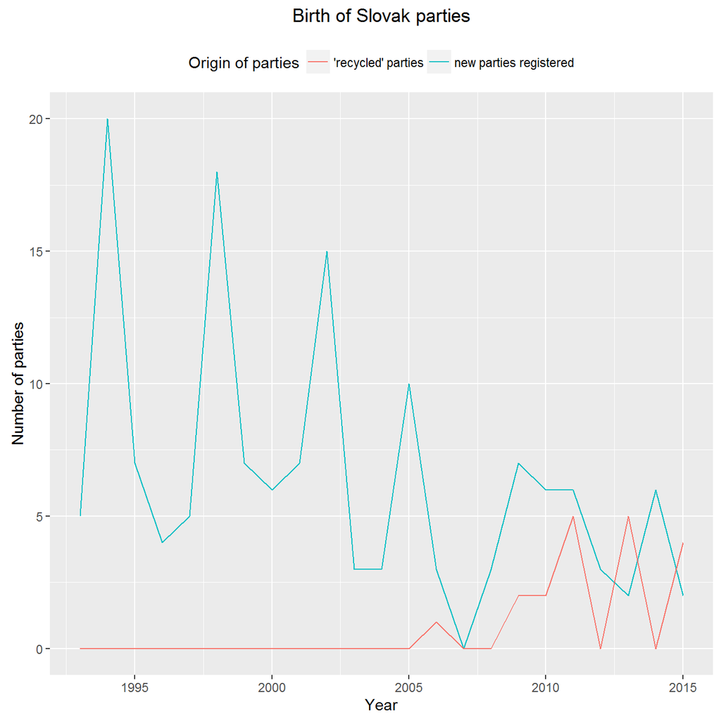

Birth of parties in the Czech and Slovak Republics

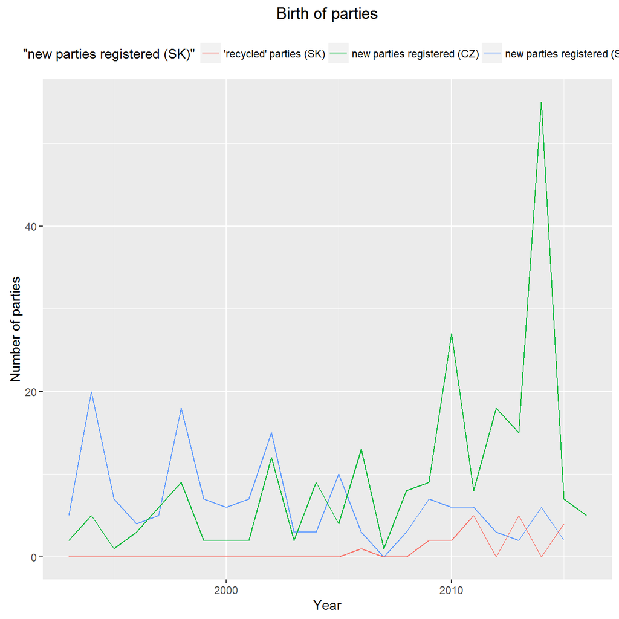

Number of competing minor parties

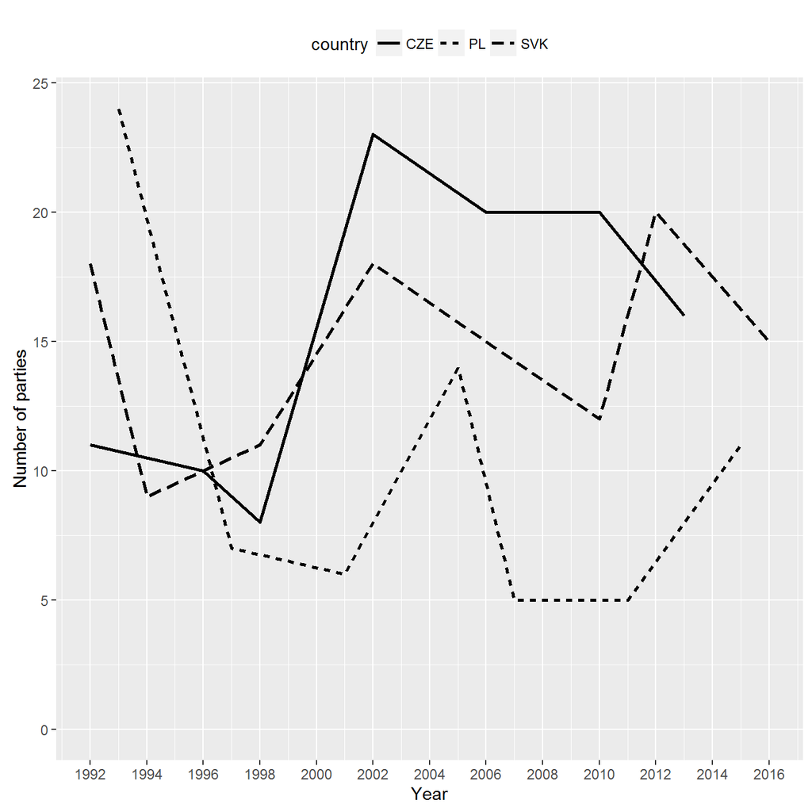

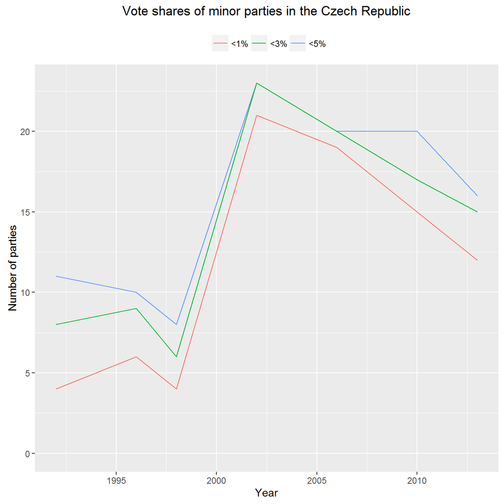

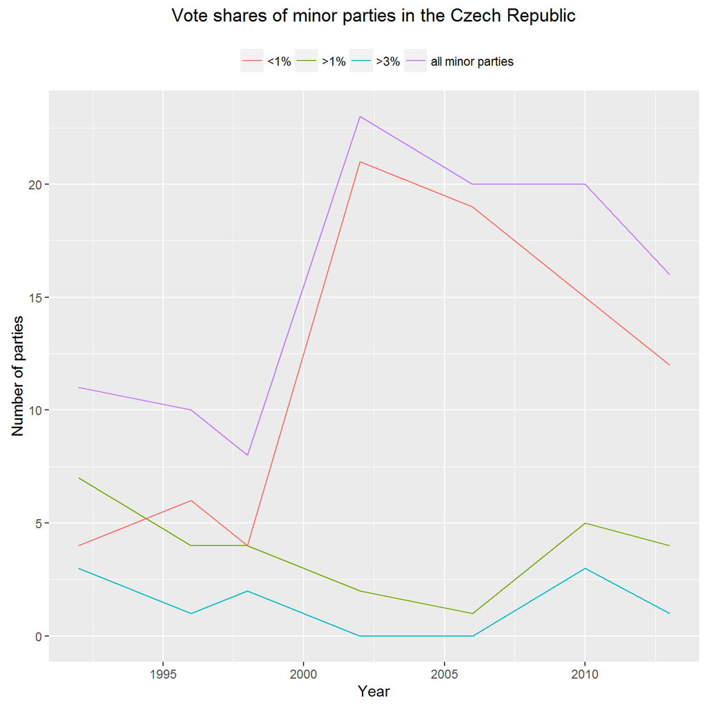

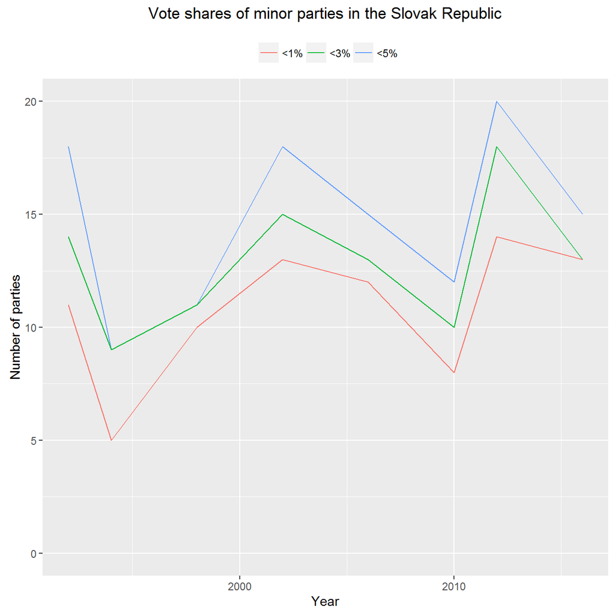

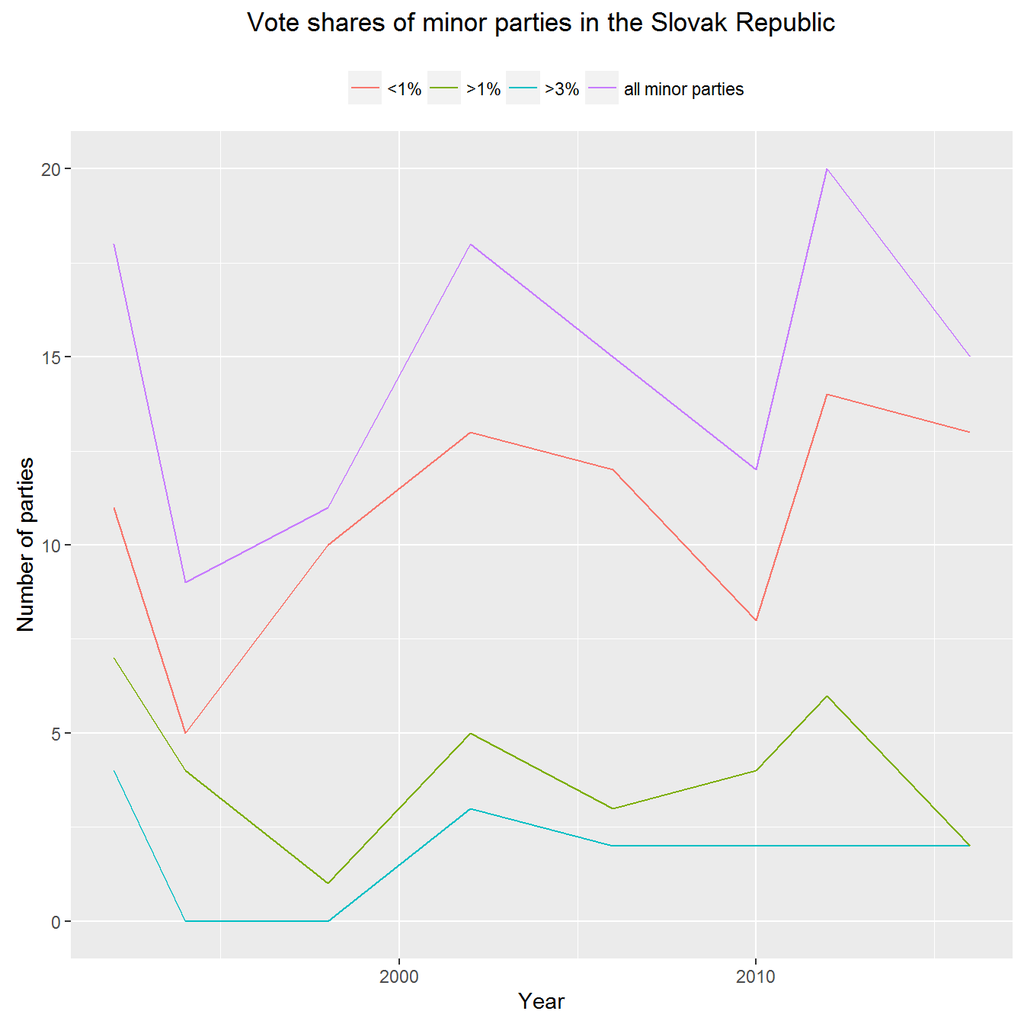

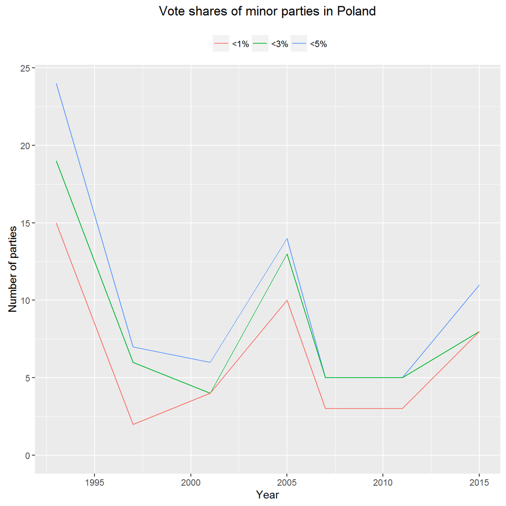

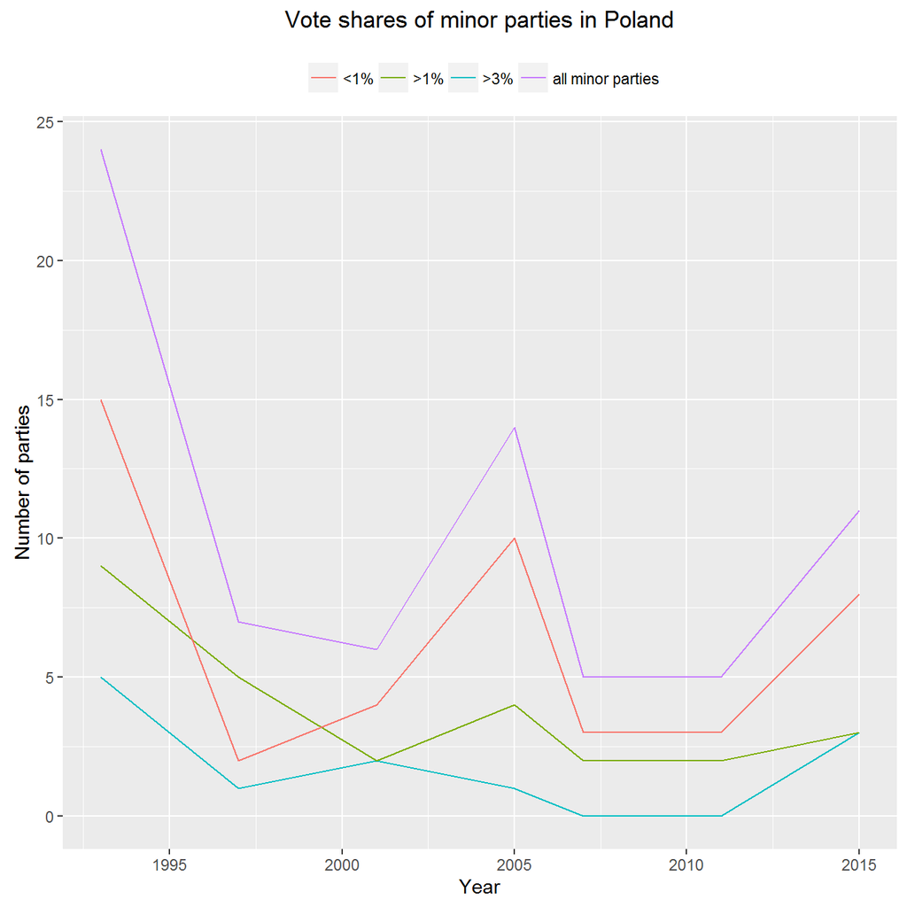

## Correlations

### (when do minor parties emerge)

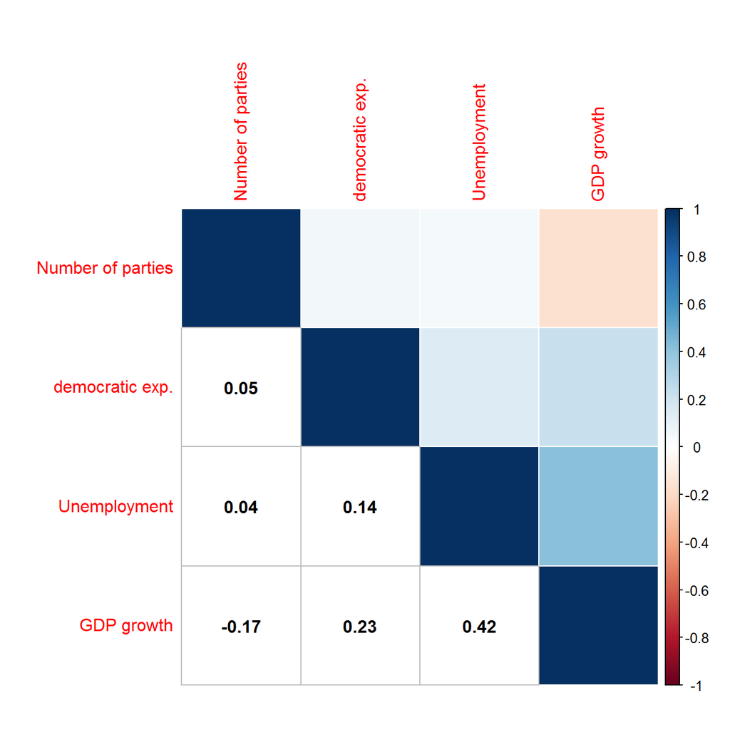

### (when do voters vote them)

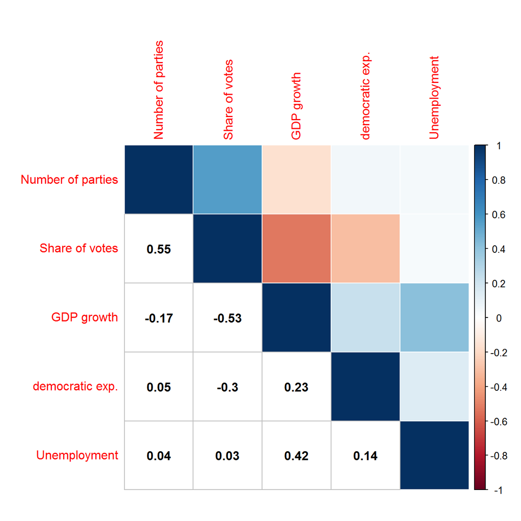

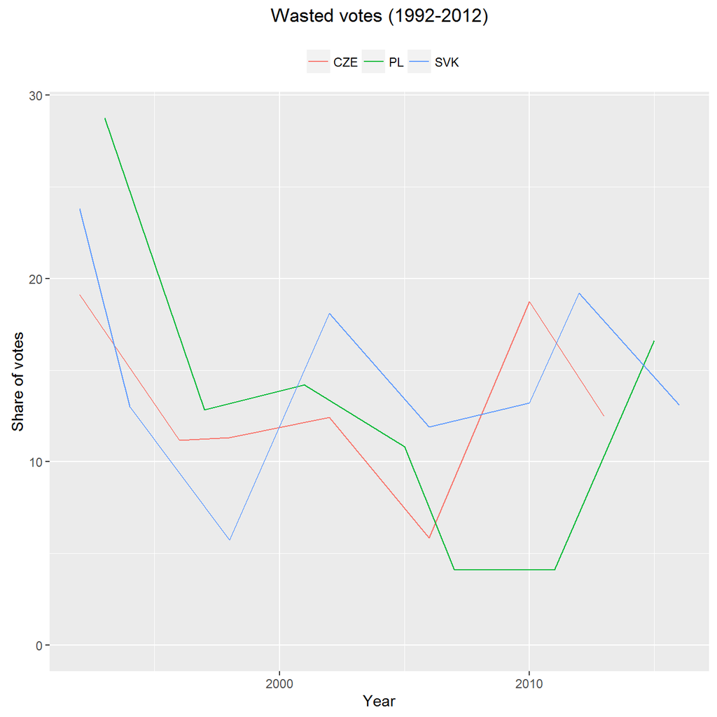

### without the CZE

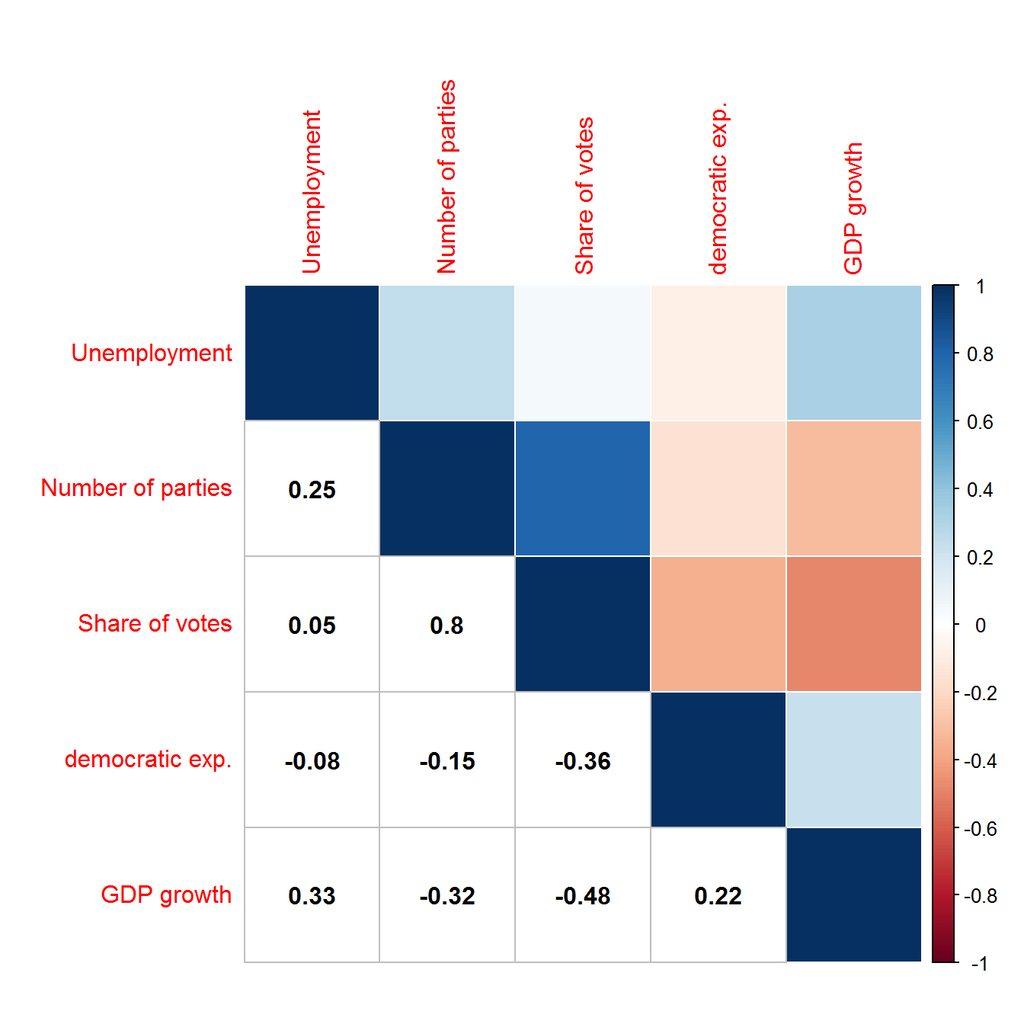

### Purifiers

```
## [1] "Number of purifiers in CZE"
```

```
##
##     1992 1996 1998 2002 2006 2010
##   1    2    4    2    5    2    3
```

```
## [1] "Number of purifiers in SVK"
```

```
##
##     1994 1998 2002 2006 2010 2012
##   1    3    3    9    9    4    6
```

```
## [1] "Number of purifiers in Poland"
```

```
##
##     1993 1997 2001 2005 2007 2011
##   1    5    3    3    6    1    2
```

### Projects of newness

```
## [1] "Number of projects of newness in CZE"
```

```
##
##     1992 1996 1998 2002 2006 2010
##   1    2    2    2   11   12    7
```

```
## [1] "Number of projects of newness in SVK"
```

```
##
##     1994 1998 2002 2006 2010 2012
##   1    2    4    2    3    4    4
```

```
## [1] "Number of projects of newness in PL"
```

```
##
##     1993 1997 2001 2005 2007 2011
##   1    5    1    1    5    1    2
```

### Prophets

```
## [1] "Number of prophets in CZE"
```

```
##
##     1996 1998 2002 2006 2010
##   1    3    3    3    3    7
```

```
## [1] "Number of prophets in SVK"
```

```
##
##     1994 1998 2002 2006 2010 2012
##   1    2    1    2    1    3    4
```

```
## [1] "Number of prophets in PL"
```

```
##
##     1993 1997 2001 2005
##   1    1    1    1    2
```

### Prolocutors

```
## [1] "Number of prolocutors in CZE"
```

```
##
##     1992 1996 1998 2002 2006 2010
##   1    2    1    1    4    3    3
```

```
## [1] "Number of prolocutors in SVK"
```

```
##
##     1994 1998 2002 2006 2010 2012
##   1    2    3    5    2    1    4
```

```
## [1] "Number of prolocutors in PL"
```

```
##
##     1993 1997 2001 2005 2007 2011
##   1   13    2    1    1    3    1
```

Notes:

- influence of electoral law (subsidies/fees for running in the elections) on number of parties (e.g. the number of projects of newness rose rapidly in 2002 due to lower fees necessary for registration a party list (500,000 CZK in 1998 vs. 15,000 CZK in 2002)). In addition, conjecture of lower constraints for running in the election and dissatisfaction with the so-called Opposition agreement (Cesta změny, Naděje and other parties).
- high number of prolocutors in Poland in the 1993 parliamentary election because of interest organizations running in the election.

Origin of parties and their functioning in the system:

- minor parties may become a shell for political entrepreneurs. Hanley (2012: 129) argues that the Public Affairs or the (Czech) Green Party were “captured and re-launched by outsiders entering the political sphere”. The logic of kidnapping a party seems irrational (except for the cases when you’re trying to establish a green party with actual green ideology and creating a second green party would probably be incomprehensible for the voters) as you pass a test of your support. A party which is not able to collect signatures will not be able to succeed in an election (Tavits wrote about that, higher constrains for running in the election prevents future losers from running). However, it was a viable strategy for far-right parties as Marián Kotleba’s People’s Party - Our Slovakia (ĽSNS) which hi-jacked the Friends of Wine Party. We may speculate that it is easier for far-right parties to attract voters than collect signatures because voting is secret but the collection of signatures takes place in the public. In addition, ĽSNS had only 44 candidates in their first election which signifies of their low social capital and membership base lacking resources for the collection of signatures.
- Besides the parties with genuine intention of running and gaining votes for themselves, minor parties may be used as “dummy parties” (instead of dummy candidates in single-mandate districts unrecognizable from other candidates). E.g. a minor party was renamed to the Ordinary People in order to prevent I. Matovič from setting up the party of the same name. Instead, he registered the Ordinary People and Independent Persons Party. Also, minor parties may be used for other dirty tricks as the Greens (Zelení) in Slovakia who used their time for TV advertisement guaranteed for every political party running in the election to air a commercial unrecognizable from a commercial of other (minor) party.

# Resources:

Jackman, Simon (2015). pscl: Classes and Methods for R Developed in the Political Science Computational Laboratory, Stanford University. Department of Political Science, Stanford University. Stanford, California. R package version 1.4.9. URL http://pscl.stanford.edu/

R Core Team (2015). R: A language and environment for statistical computing. R Foundation for Statistical Computing, Vienna, Austria. URL https://www.R-project.org/.

Sikk, A. 2011. Newness as a winning formula for new political parties. *Party politics* 18(4) 465–486, DOI: 10.1177/1354068810389631.